# Lab with Solutions

Author

Ashley Martinez, Drew Collopy, Hannah Stackpole

# Setup

```r
#load packages here
library(tidyverse)
library(gtsummary)
library(ggplot2)
library(ggthemes)
library(maps)
library(mapproj)
library(patchwork)
```

# About the Data

Please download the following data and then take the time to read the paragraphs below. It is necessary to understand the data.

Download test score data

Download covariate data

The data for this lab comes from The Stanford Education Data Archive (SEDA), which is maintained by the Educational Opportunity Project (EOP) at Stanford University (https:\edopportunity.org). There is a plethora of nationwide data on academic achievement and school demographics/inequality.

We will focus on a “long” dataset that contains math and Reading/English Language Arts (RLA) performance for administrative school districts in the U.S. for the 2008-09 through 2018-19 and 2021-22 through 2024-25 school years.

While the construction of the data uses a complex model, it is important to understand that these are not raw test scores. Rather, they are cohort-standardized scores. This means that the values can be interpreted as the number of standard deviations above or below the national average scores of four reference groups (students who were in fourth grade in the years 2009, 2011, 2013, and 2015).

Practically speaking, this means that the estimates are comparable across time and across places, but not across grades or subjects. Please keep this in mind when designing graphs/analyses. If you would like to learn more about our data, you can check out the following resources:

- [Technical Documentation](https://stacks.stanford.edu/file/hm970gr1371/SEDA_documentation_v2025.1.pdf#page=4.36)
- [SEDA site (information about the project and downloadable codebooks with variable descriptions)](https://edopportunity.org/trends/data/downloads/#testscore-2025)

*Note: the relevant codebooks are `seda_codebook_admindist_2025.1` and `seda_codebook_cov_admindist_2025.1`. You will need to navigate to the sheets that match the file names for our specific datasets.*

Below are descriptions of the test data variables we will focus on, but you are encouraged to check out the codebook if you wish to explore other variables.

| Variable | Description |
| --- | --- |
| `sedaadmin` | SEDA Admin ID |
| `sedaadminname` | Administrative District Name |
| `subject` | Tested Subject |
| `grade` | Tested Grade |
| `year` | Spring of Tested Year |
| `fips` | State FIPS Code |
| `stateabb` | State Abbreviation |
| `cs_mn_all` | Admin. Dist. Subject-Grade-Year Average |
| `tot_asmt_all` | Total Number Tested in the Subject-Grade-Year |
| `cs_mn_fem` | Admin. Dist. Subject-Grade-Year Average Female |
| `tot_asmt_fem` | Number Females Tested in the Subject-Grade-Year |
| `cs_mn_mal` | Admin. Dist. Subject-Grade-Year Average Male |
| `tot_asmt_mal` | Number Males Tested in the Subject-Grade-Year |

The covariate data contains a variety of data on city size, school locale, school demographics, student poverty rates (measured by free/reduced school lunch status), household income and unemployment data, and school diversity/“segregation” measures.

# Reading in the Data

```r
test_data <- read_csv("seda_admindist_long_cs_2025.1.csv")
cov_data <- read_csv("seda_cov_admindist_long_2025.1.csv")
```

# Section 1: Cleaning and Understanding the Data

**Question 1: Cleaning the data** Before we begin our analysis, we need to clean and join our two datasets. Complete the following steps:

1. For test_data, filter it to only include states that have the abbreviation CA for California
2. Then select the columns shown in the “About the Data” above
3. Rename the columns to something that is easier to read
4. Now join the two datasets

```r
test_data_clean <- test_data |>
  filter(stateabb == "CA") |>
  select(sedaadmin, sedaadminname, subject, grade, year, fips, stateabb,
         cs_mn_all, tot_asmt_all, cs_mn_fem, tot_asmt_fem, cs_mn_mal, tot_asmt_mal) |>
  rename(avg_score_all = cs_mn_all,
         avg_score_fem = cs_mn_fem,
         avg_score_mal = cs_mn_mal)

cov_data_clean <- cov_data |>
  select(sedaadmin, grade, year, totenrl, perfl, sesall, perwht, perblk, perhsp, rural, perfrl, rswhtblk)

ca_data <- test_data_clean |>
  left_join(cov_data_clean, by = c("sedaadmin", "grade", "year"))

ca_data |>
  distinct(sedaadmin) |>
  nrow()
```

```
[1] 1509
```

```r
ca_data <- ca_data |>
  filter(!is.na(avg_score_all))
```

**Question 2: Summary table**

Start by creating a function called summary_table() that takes in test_data data set and shows the achievement scores based on grade level and subject

- Group by subject and grade
- Find the average achievement score using cs_mn_all
- Determine missing values in cs_mn_all
- Return the summary table

```r
summary_table <- function(data) {
  data |>
    group_by(subject, grade) |>
    summarise(
      avg_score = mean(cs_mn_all, na.rm = TRUE),
      missing_values = sum(is.na(cs_mn_all)),
      .groups = "drop"
    )
}

summary_table(test_data)
```

```
# A tibble: 12 × 4
   subject grade avg_score missing_values
   <chr>   <dbl>     <dbl>          <int>
 1 mth         3  -0.00599              0
 2 mth         4  -0.0319               0
 3 mth         5  -0.0493               0
 4 mth         6  -0.0397               0
 5 mth         7  -0.0355               0
 6 mth         8  -0.0271               0
 7 rla         3   0.0144               0
 8 rla         4  -0.00722              0
 9 rla         5  -0.0411               0
10 rla         6  -0.0399               0
11 rla         7  -0.0406               0
12 rla         8  -0.0341               0
```

**Question 3: Demographics**

What are the demographics of California districts in this study? Investigate the variables perwht, perblk, and perhsp and summarize your findings in ~3 complete sentences. Reminder: perwht= Percent White Students perblk= Percent Black Students perhsp= Percent Hispanic Students

```r
ca_data |>
  distinct(sedaadmin, .keep_all = TRUE) |>
  select(perwht, perblk, perhsp) |>
  summary()
```

```
     perwht           perblk            perhsp
 Min.   :0.0000   Min.   :0.00000   Min.   :0.0000
 1st Qu.:0.0624   1st Qu.:0.00000   1st Qu.:0.1600
 Median :0.3198   Median :0.02269   Median :0.3756
 Mean   :0.3549   Mean   :0.07253   Mean   :0.4397
 3rd Qu.:0.6090   3rd Qu.:0.07407   3rd Qu.:0.7214
 Max.   :1.0000   Max.   :1.00000   Max.   :1.0000
 NA's   :9        NA's   :9         NA's   :9
```

# Section 2: Data Visualization

**Question 4: Exploring ca_data**

- color the boxplots by subject
- add a point representing the mean for each boxplot
- add an appropriate title and axis labels

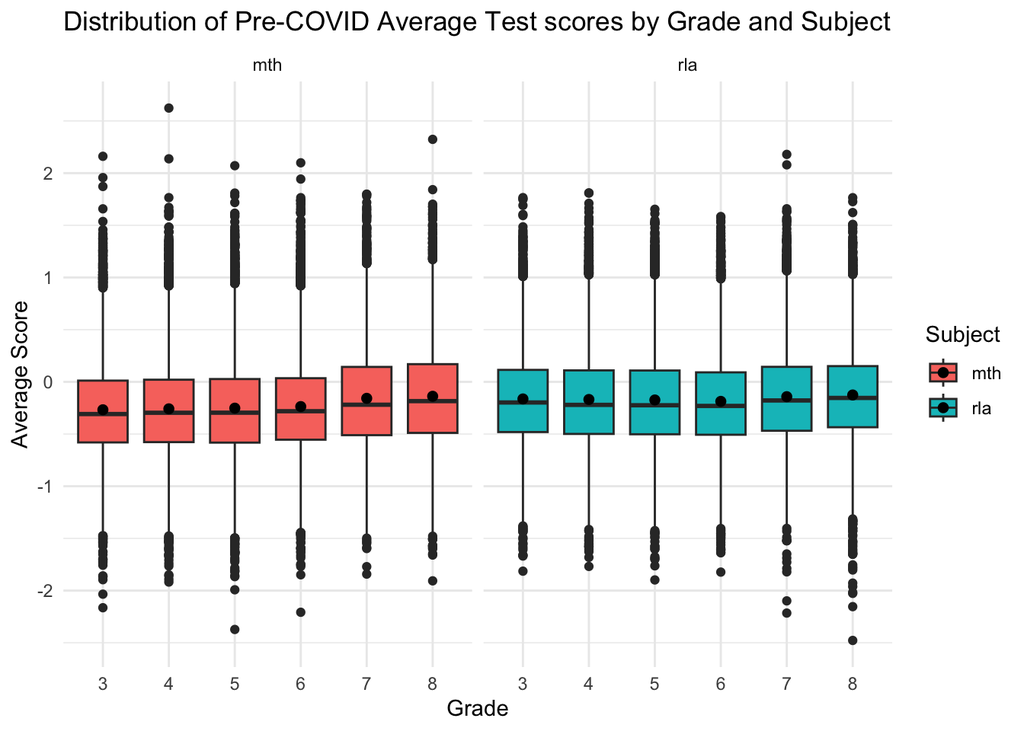

```r
ca_data |>
  filter(year < 2020) |>
  ggplot(mapping = aes(x = factor(grade), y = avg_score_all, fill = subject)) +
  geom_boxplot() +
  stat_summary(fun = mean, geom = "point", shape = 20, size = 3, color = "black") +
  facet_wrap(~subject) +
  labs(title = "Distribution of Pre-COVID Average Test scores by Grade and Subject",
       x = "Grade",
       y = "Average Score",
       fill = "Subject") +
  theme_minimal()
```

**Question 5: Gender Gap Over Time** Using ca_data, calculate the gender gap in average scores from each district, subject, and year. The gender gap is defined as avg_score_mal - avg_score_fem.

Then, plot the statewide average gender gap over time, separated by subject. Make sure to add an appropriate title and axis labels.

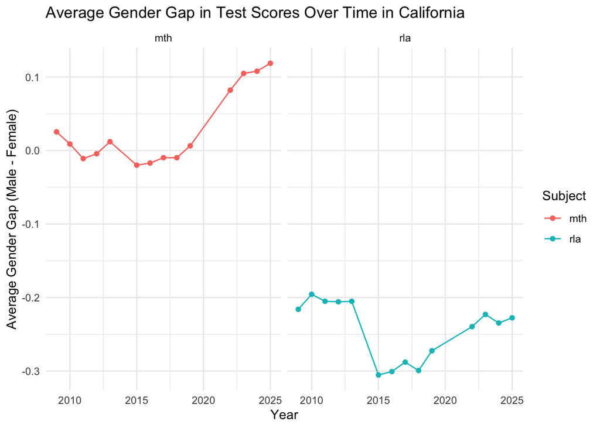

```r
ca_data |>
  mutate(gender_gap = avg_score_mal - avg_score_fem) |>
  filter(!is.na(gender_gap)) |>
  group_by(year, subject) |>
  summarize(avg_gap = mean(gender_gap)) |>
  ggplot(mapping = aes(x = year, y = avg_gap, color = subject)) +
  geom_line() +
  geom_point() +
  facet_wrap(~subject) +
  labs(title = "Average Gender Gap in Test Scores Over Time in California",
       x = "Year",
       y = "Average Gender Gap (Male - Female)",
       color = "Subject") +
  theme_minimal()
```

**Hint:** You should create a new variable that is the state average of the user-given variable.

*The average will not be the best state-wide measure of the variable as it is the average of the district data, not weighted by district size. We will ignore this limitation for the sake of function-writing practice!

Please see below for an example of the desired output.

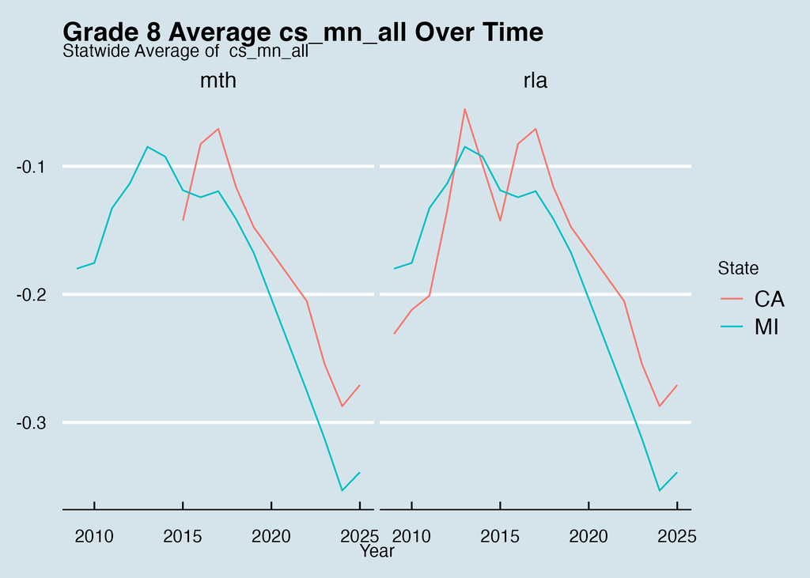

Demo Output

**Tip**

Creating titles that include the variable names is tricky. Use the following code at the start of your function: `var_name <- deparse(substitute(var))`. Then you can use `paste()` later to create nice labels. Do not stress this too much.

```r
states_plot_func <- function(grade_level, var, states){
  stopifnot(is.numeric(grade_level))
  stopifnot(length(states) < 3)
  stopifnot(is.character(states))

  var_name <- deparse(substitute(var))

  test_data |>
    filter(stateabb %in% states,
           grade == grade_level) |>
    group_by(stateabb, year) |>
    mutate(avg := mean({{ var }})) |>
    ggplot(mapping = aes(x = year,
                       y = avg,
                       color = stateabb)) +
    geom_line() +
    facet_wrap(vars(subject)) +
    labs(title = paste("Grade", grade_level, "Average", var_name, "Over Time"),
       subtitle = paste("Statwide Average of ", var_name),
       y = NULL,
       x = "Year",
       color = "State") +
    theme_economist() +
    theme(legend.position = "right")
}

demo <- states_plot_func(8, cs_mn_all, c("CA", "MI"))

ggsave("demo.png", plot = demo)
```

# Section 3: Regression Analysis

**Question 7: Regression**

We are going to run a simple model where the outcome variable is `cs_mn_all` and there are three predictors from the covariate data:

- `rural`: proportion students in rural locale schools
- `perfrl`: percent free and reduced lunch
- `rswhtblk`: the relative diversity index captures white-black differences in exposure to white students at the average white/black student’s school within the unit

Format the model output nicely.

```r
mod_1 <- lm(avg_score_all ~ rural + perfrl + rswhtblk, data = ca_data)
tbl_regression(mod_1, intercept = TRUE)
```

| **Characteristic** | **Beta** | **95% CI** | **p-value** |
| --- | --- | --- | --- |
| (Intercept) | 0.60 | 0.59, 0.60 | <0.001 |
| rural | -0.20 | -0.21, -0.20 | <0.001 |
| perfrl | -1.4 | -1.4, -1.4 | <0.001 |
| rswhtblk | 0.07 | 0.05, 0.09 | <0.001 |

Abbreviation: CI = Confidence Interval

**Question 8: Exploring Multicollinearity**

Think about the three predictors we included in our regression. Do you think any might be highly correlated?

Multicollinearity is the problem that arises when predictors are highly correlated, which creates problems such as large standard errors and coefficients with unexpected signs. This is because the model doesn’t know how much of the variation is explained by the correlated predictors.

There are fancier ways to check for multicollinearity, but we will go the simple route and create plots to explore the relationship between predictors.

Please:

- create **three** plots, one for each pair of predictors
- format them nicely
- write 2-3 sentences about which ones have a strong relationship
- bonus points if you explore the [`patchwork`](https://patchwork.data-imaginist.com/articles/patchwork.html) package to arrange the plots nicely

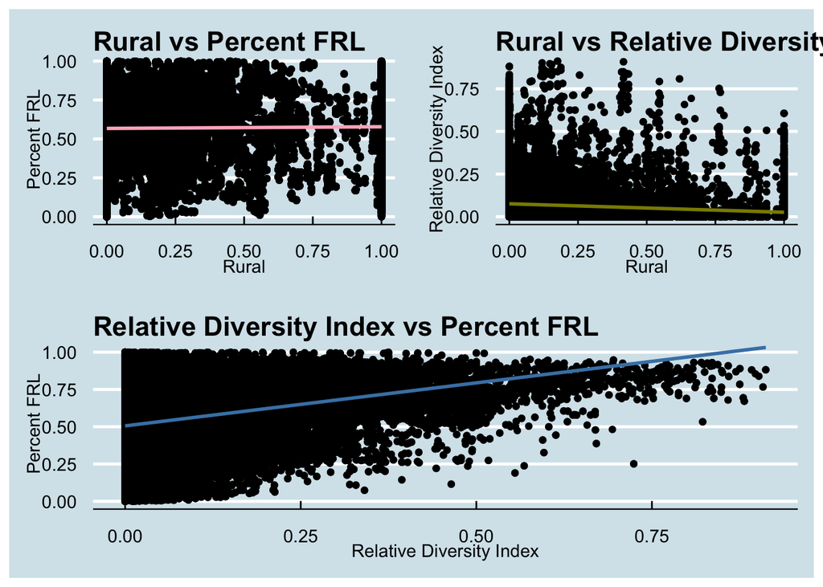

```r
p_1 <- ca_data |>
  ggplot(mapping = aes(x = rural,
                       y = perfrl)) +
  geom_point() +
  geom_smooth(method = "lm",
              color = "pink1") +
  labs(title = "Rural vs Percent FRL",
       x = "Rural",
       y = "Percent FRL") +
  theme_economist()

p_2 <- ca_data |>
  ggplot(mapping = aes(x = rural,
                       y = rswhtblk)) +
  geom_point() +
  geom_smooth(method = "lm",
              color = "yellow4") +
  labs(title = "Rural vs Relative Diversity Index",
       x = "Rural",
       y = "Relative Diversity Index") +
  theme_economist()

p_3 <- ca_data |>
  ggplot(mapping = aes(x = rswhtblk,
                       y = perfrl)) +
  geom_point() +
  geom_smooth(method = "lm",
              color = "steelblue") +
  labs(title = "Relative Diversity Index vs Percent FRL",
       x = "Relative Diversity Index",
       y = "Percent FRL") +
  theme_economist()

(p_1 + p_2) / p_3
```

**Question 9: Fix Our Regression**

Based on the results from the previous question, let’s fix our regression. Remove the predictors you think should be removed (consider their correlation) and interpret the results of the regression in context. You may also leave them all in. Up to you, but justify your answer.

**Tip**

Be sure to nicely format your results!

```r
mod_2 <- lm(avg_score_all ~ rural + perfrl + rswhtblk, data = ca_data)
tbl_regression(mod_2, intercept = TRUE)
```

| **Characteristic** | **Beta** | **95% CI** | **p-value** |
| --- | --- | --- | --- |
| (Intercept) | 0.60 | 0.59, 0.60 | <0.001 |
| rural | -0.20 | -0.21, -0.20 | <0.001 |
| perfrl | -1.4 | -1.4, -1.4 | <0.001 |
| rswhtblk | 0.07 | 0.05, 0.09 | <0.001 |

Abbreviation: CI = Confidence Interval

None of the scatterplots showed egregious correlation, so it is fine to keep all the predictors.

# Section 4: Chi-Square Test of Independence

**Question 10: Chi Square Test of Independence** Use chisq.test() to carry out a Chi-square test of independence between student demographic characteristics and whether a district is classified as rural or urban. - Use ‘perhsp’ as your demographic characteristic - Convert ‘perhsp’ into a categorical variable (high vs low representation)

```r
chi_data <- ca_data |>
  distinct(sedaadmin, .keep_all = TRUE) |>
  filter(!is.na(perhsp), !is.na(rural)) |>
  mutate(
    hispanic_level = ifelse(
      perhsp > median(perhsp, na.rm = TRUE),
      "High Hispanic",
      "Low Hispanic"
    ),
    district_location = ifelse(
      rural > 0.5,
      "Rural",
      "Urban"
    )
  )

with(
  chi_data,
  table(hispanic_level, district_location)
)
```

```
               district_location
hispanic_level  Rural Urban
  High Hispanic   125   625
  Low Hispanic    200   550
```

```r
with(
  chi_data,
  chisq.test(table(hispanic_level, district_location))
)
```

```
    Pearson's Chi-squared test with Yates' continuity correction

data:  table(hispanic_level, district_location)
X-squared = 21.51, df = 1, p-value = 3.521e-06
```

# Section 5: Mapping Test Scores

**Question 11: Mapping State Averages**

Because our data are comparable across places, but not grades, we want to make a simple map to look at nationwide patterns.

Start with the full `test_data` and filter to grade 8 in the year 2013. Use the `map_data()` function to create a dataframe of **state** latitudes, longitudes, and FIPS numbers, then show the **state average of `cs_mn_all` on the map.**

Please also customize the color gradient. [Use this site to choose a color scheme](https://colorbrewer2.org/#type=sequential&scheme=Greens&n=7). *Note: Do not choose the default blue scale.*

Most of the plot theme code is provided, but you are required to **add code** to:

- change the legend title
- add a nice title
- edit the provided code to increase the margins so the title has room to breathe

**Tip**

You will need to aggregate your data to the **state level** with some summary function and join with the `state_map` data.

Note: Some states have missing data. Do not worry about this.

```r
state_map <- map_data("state")
```

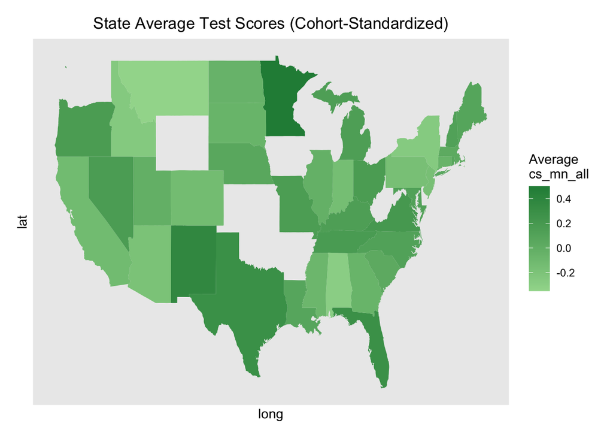

```r
test_data |>
  filter(grade == 8,
         year == 2013) |>
  group_by(fips) |>
  summarise(avg_cs_mn_all = mean(cs_mn_all, na.rm = TRUE)) |>
  left_join(state_map, by = join_by(fips == group)) |>
  ggplot(mapping = aes(x = long,
                       y = lat,
                       group = fips,
                       fill = avg_cs_mn_all)) +
  geom_polygon() +
  scale_fill_gradient(low = "#a1d99b", high = "#238b45") +
   theme(plot.title = element_text(hjust = 0.5),
        panel.border = element_blank(),
        panel.grid.major = element_blank(),
        panel.grid.minor = element_blank(),
        axis.text = element_blank(),
        axis.ticks = element_blank(),
        plot.margin = margin(0.5, 0.5, 0.5, 0.5, "cm")) + #make these 0 on student version to edit
  labs(fill = "Average \ncs_mn_all", #leave labs() out of student version
       title = "State Average Test Scores (Cohort-Standardized)")
```